# Statistics for Bioengineering - Week 1

Bill Cresko

# Week 1: Foundational Data Science Tools

## Week 1 Topics

- Unix & shell commands
- R scripts & reproducible analysis
- Use of GenAI
- Tidy data and data wrangling
- Markdown

**Note**

**Readings:** Chapters 1-8, Appendix A1

## Packages for This Week

- Install
- Load

```r
# Install packages (run once)
install.packages(c("tidyverse", "knitr", "readxl"))
```

```r
# Load packages
library(tidyverse)    # Data manipulation & visualization (includes ggplot2, dplyr, tidyr)
library(knitr)        # Document generation
library(readxl)       # Read Excel files
```

**Tip**

The **tidyverse** is a collection of packages including: ggplot2, dplyr, tidyr, readr, purrr, tibble, stringr, and forcats.

## Statistics for Bioengineers and Bioscientists

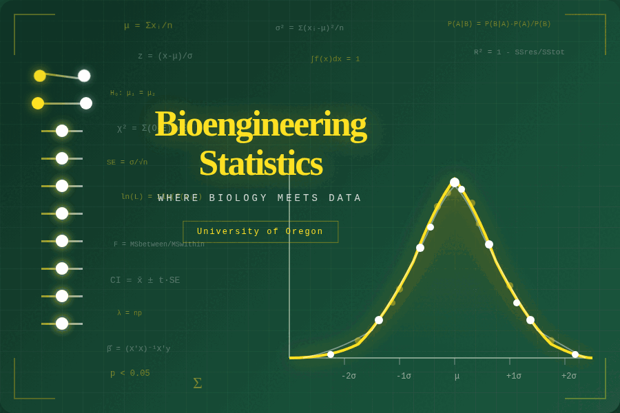

Welcome to the course! This term we will build your skills in statistical thinking, programming in R and Unix, reproducible research practices, and data visualization.

## Goals of the Course

**This is a practical course and we will learn by doing**

- Teach fundamental skills for your scientific careers
- Provide broad coverage of modern statistics
- Provide computational tools necessary for your work
- Prepare you for more advanced statistics and programming

## What Will You Learn?

- Read and write code in Unix and R
- Implement reproducible research practices
- Exploratory data analysis and visualization
- Probability, distributions, and sampling
- Experimental design and hypothesis testing
- Statistical analyses (t-tests, contingency tests)
- Linear and non-linear modeling
- Classical machine learning
- Ordination (PCA, tSNE, UMAP)

[figure not shown]

Source: George Nakashima Conoid Chair, Nakashima Woodworkers

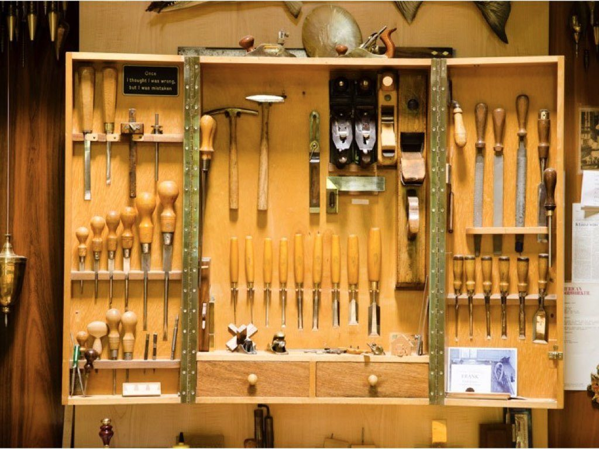

Source: Photo illustration (public domain)

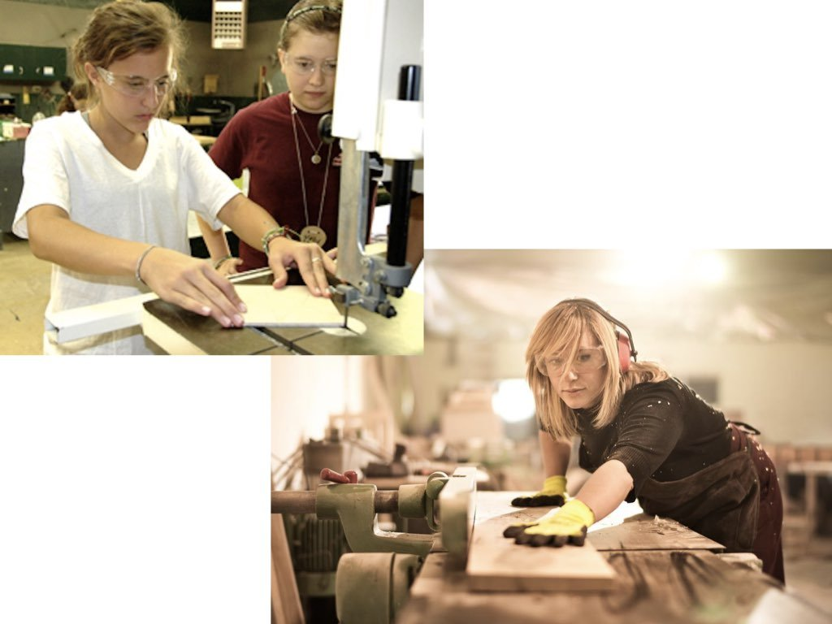

Source: Photo illustration (public domain)

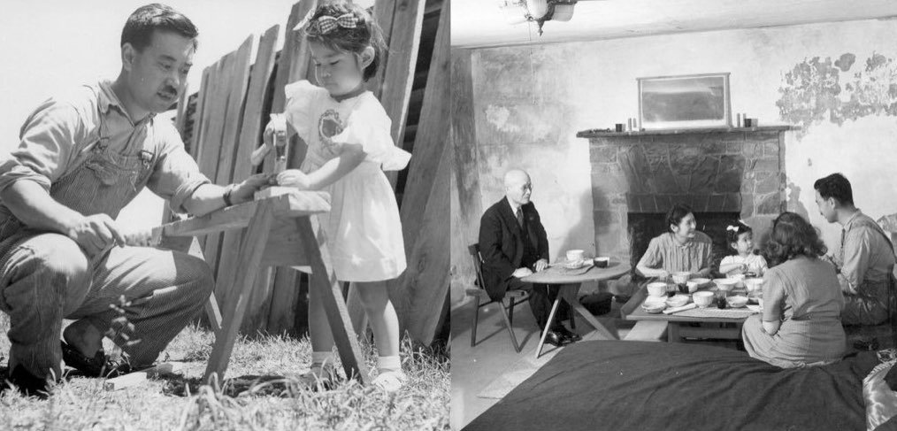

Source: Photo illustration (public domain)

## Class Logistics

**Schedule:** Tuesdays and Thursdays, 4:00pm - 5:50pm in KC107

Most of class time will be hands-on coding practice.

**Assignments:**

- Weeks 2-9: Coding and statistics homework
- Week 11: Final coding project designing scripts for your research

## Required Materials

- Access to a laptop running Windows, MacOS, or Linux
- Announcements and assignments posted on Canvas
- Course material: https://wcresko.github.io/BioE_Stats_Wi2026/
- Reading material: https://wcresko.github.io/BioE_Stats_Book/

**No textbooks or purchases required!**

## Class Introductions

**Who are you?**

- Your name and year in grad school
- Home lab or rotation lab
- What is your good news this week?
- What has your experience with programming/statistics been like?

# Why Statistics & Coding?

## Why Do We Need Statistics?

**The Problem:** We almost never know the world perfectly, but still need to draw conclusions or make decisions. We estimate parameters from samples and test hypotheses using data.

**The Solution:** Well-known mathematical rules help us do this. Computers let us apply them quickly and visualize large amounts of data.

**What statistics enables:**

- Point estimates and confidence intervals
- Experimental design and hypothesis testing
- Data reduction of highly dimensional data

**Foundation Required**

We need a firm understanding of probability, sampling, and distributions.

## Why Do We Need Coding?

- Incredibly fast and powerful for repeated actions
- Handles large datasets that Excel and GUIs can’t manage
- Access to thousands of free programs made for and by scientists
- Commands work identically across platforms and on clusters like Talapas

**The Most Important Reason**

**REPRODUCIBILITY** — You can keep your scripts to see exactly what was done

## Coding vs. Scripting

| Type | Description | Examples | Speed | Flexibility |
| --- | --- | --- | --- | --- |
| **Coding** | Uses compilers to translate code | C++, Fortran | Faster | Less flexible |
| **Scripting** | Interpreted on the fly | Python, R, Julia | Slower | More flexible |

**Note**

The distinction has become fuzzy—most modern pipelines combine both approaches.

## Programming Languages

Programming languages are called *languages* for a reason:

- Learning to program is like learning a new spoken language
- Learning one helps you learn another
- **Use it or lose it!** Practice is the best way to maintain skills

**Remember**

Computers are literal! You must use explicit, pre-defined phrases to tell your computer exactly what you want.

# Installing Programs

## Platform Considerations

**Note**

- Mac and Linux use the same shell language
- Windows requires additional setup (WSL2)
- R and RStudio work on any platform

## Installing R and RStudio

**R Installation:**

- Download from: https://www.r-project.org
- Can run from command line or on clusters

**RStudio Installation:**

- Download from: http://www.rstudio.com
- Use the Desktop Open Source (Free) version
- Provides helpful features like code completion and debugging

## RStudio

[figure not shown]

RStudio interface screenshot

Source: RStudio IDE, Posit Software PBC

## Accessing the Shell

- **Mac users**: Open the “Terminal” app or use ‘iTerm2’
- **Linux users**: Open one of several “Terminal” apps

**Windows users have additional setup**

See the next slides for WSL2 installation

## Accessing the Shell — Windows

**Installation Steps:**

1. Guide: https://ubuntu.com/tutorials/install-ubuntu-on-wsl2-on-windows-10
2. Run Windows PowerShell as administrator
3. Install WSL2 by typing `wsl --install`
4. Restart your computer
5. Search for and install Ubuntu from Microsoft Store

**Alternative:** Type `wsl --install -d ubuntu` on PowerShell to do steps 3-5 at once

## Accessing the Shell — Windows

- Open `Ubuntu` and set up a username and password (doesn’t need to match Windows login)
- Note that this is the `Ubuntu` Linux operating system that you installed, not the Windows Powershell
- Now you can use the `Terminal` application in Ubuntu
- Run `sudo apt update` then `sudo apt upgrade` to ensure everything is current
- Create folders and files within your Ubuntu folder
- In addition, you can access your Windows files and folders using `cd /mnt/c`

# The Unix Shell

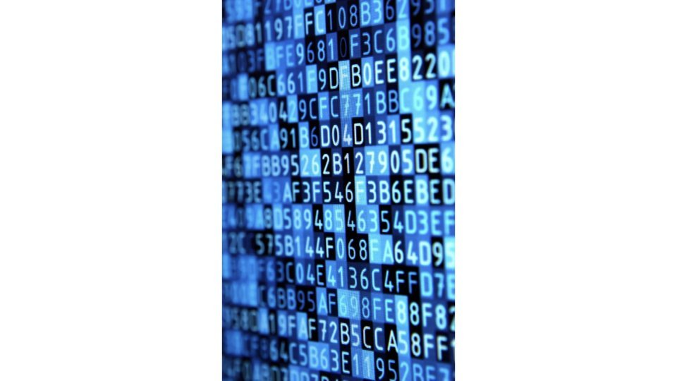

## What is Unix?

- A scripting language developed in 1969, released in 1973
- Serves as the base language for many programs and computers
- Linux is an open-source version of the same language
- Runs Apple OSX Macs, Linux Workstations, Google Android, Virtual Machines….

## What is a Shell?

- The ‘shell’ is a program that takes commands and gives them to the operating system
- The most common is `Bash`, but also `Tsh` and `Zsh`
- `Bash` acts as the shell in Macs and Linux
- You access the `bash` shell via a terminal window

## The Mac Terminal

[figure not shown]

[figure not shown]

## Terminal Within RStudio

[figure not shown]

## Shell Command Structure

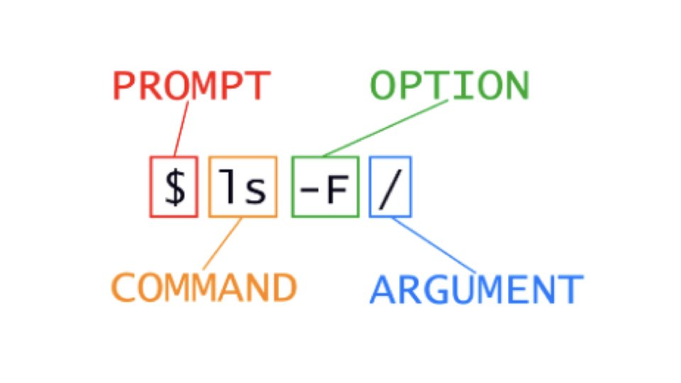

| Component | Description |
| --- | --- |
| **Prompt** | Indicates computer is ready to accept a command |
| **Command** | Tells computer to do a specific task |
| **Options** | Change the behavior of a command |
| **Argument** | What the command should operate on |

## Shell Command Structure (SVG)

[figure not shown]

| Component | Description |
| --- | --- |
| **Prompt** | Indicates computer is ready to accept a command |
| **Command** | Tells computer to do a specific task |
| **Options** | Change the behavior of a command |
| **Argument** | What the command should operate on |

# Navigation Commands

## The way you normally navigate

[figure not shown]

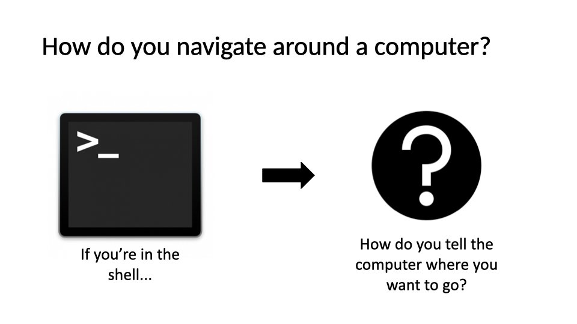

## How is a Computer Organized?

- System of directories (folders) and files
- `/` = the root directory, which holds all other directories
- `~` is shorthand for your home folder
- The “path” refers to file location (e.g., `/Users/wcresko/Documents`)

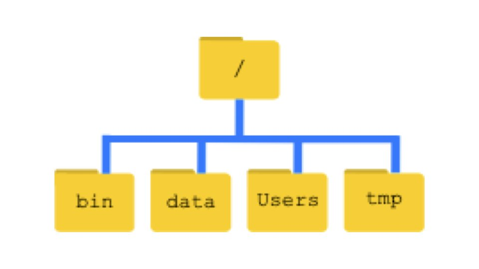

## File System Structure (SVG)

[figure not shown]

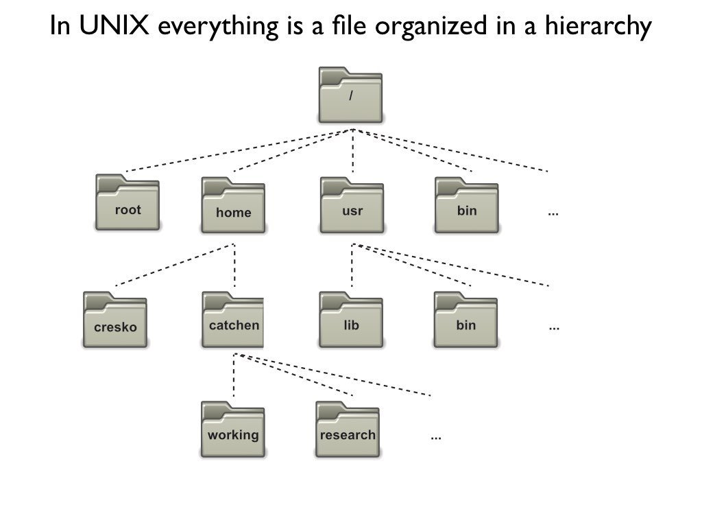

## UNIX File Hierarchy (SVG)

[figure not shown]

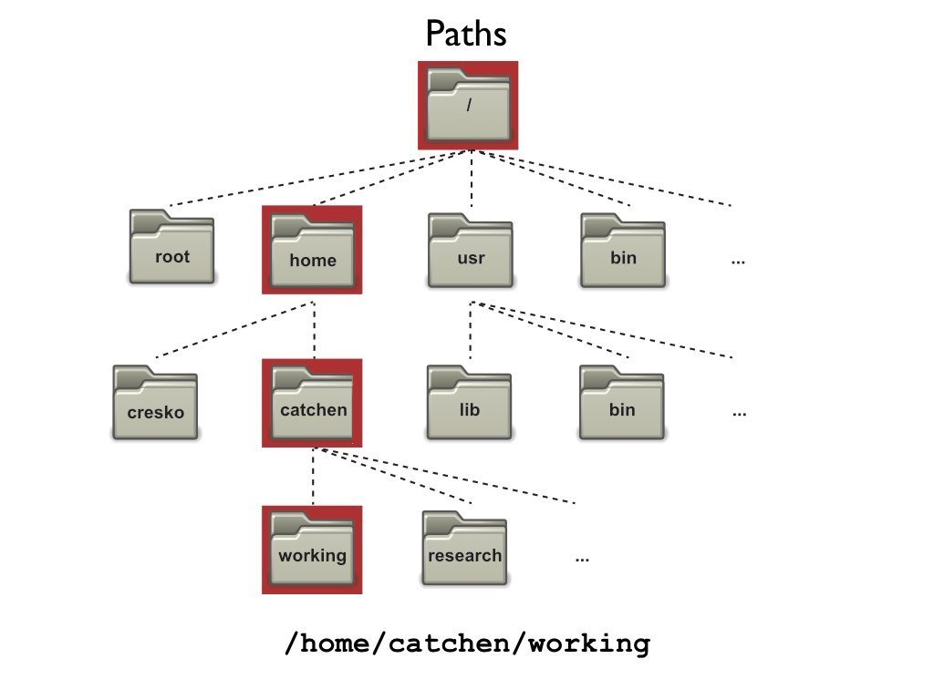

## Paths (SVG)

[figure not shown]

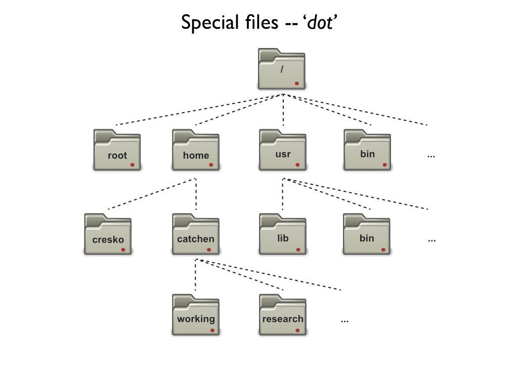

## Special Files – ‘dot’ (SVG)

[figure not shown]

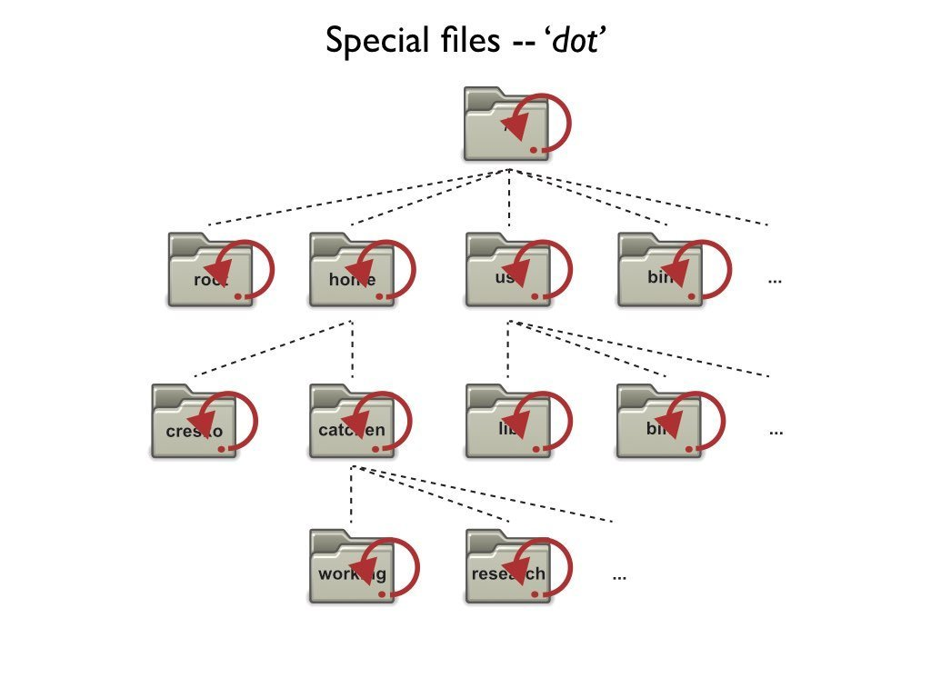

## Special Files – ‘dot’ Self-Reference (SVG)

[figure not shown]

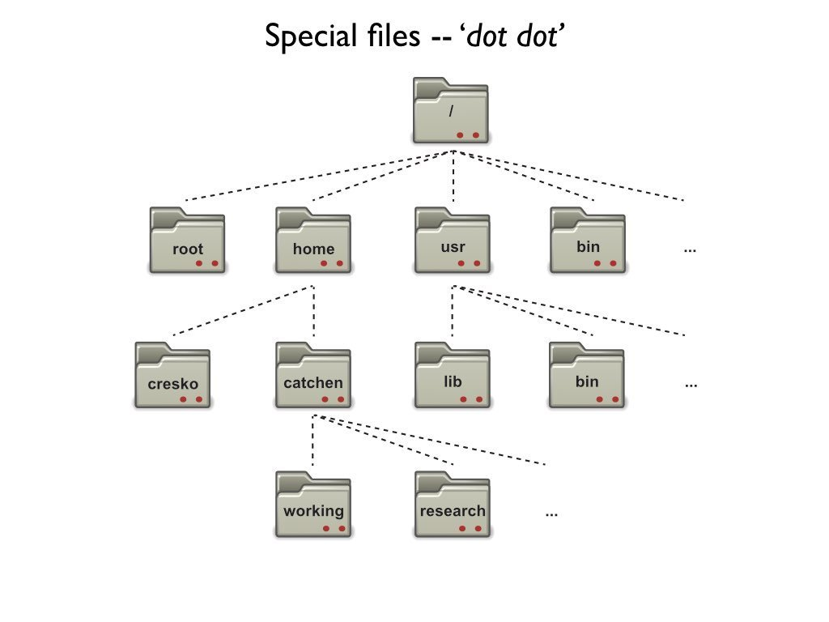

## Special Files – ‘dot dot’ (SVG)

[figure not shown]

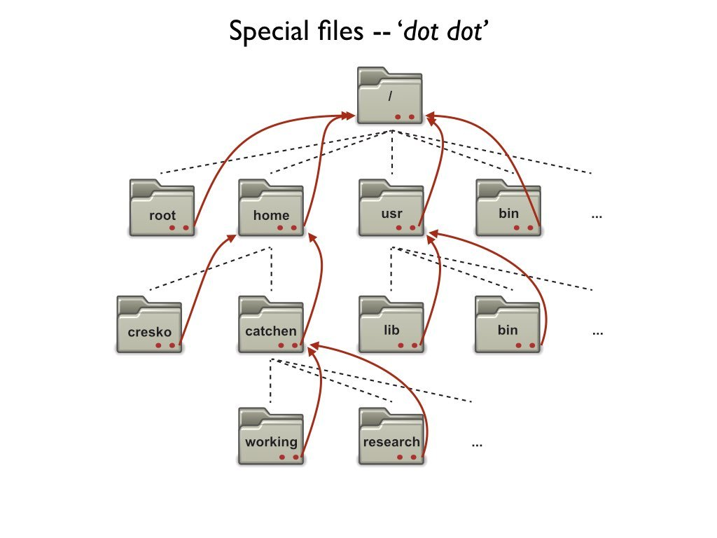

## Special Files – ‘dot dot’ Navigation (SVG)

[figure not shown]

## Relative and Absolute Paths

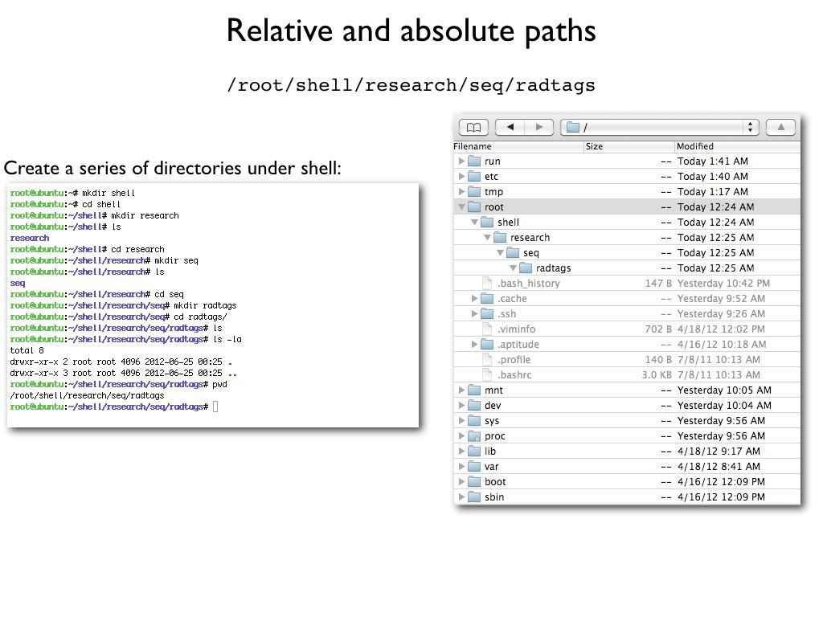

## Relative and Absolute Paths

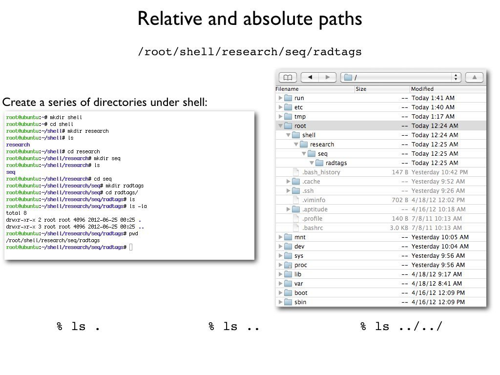

## Relative and Absolute Paths

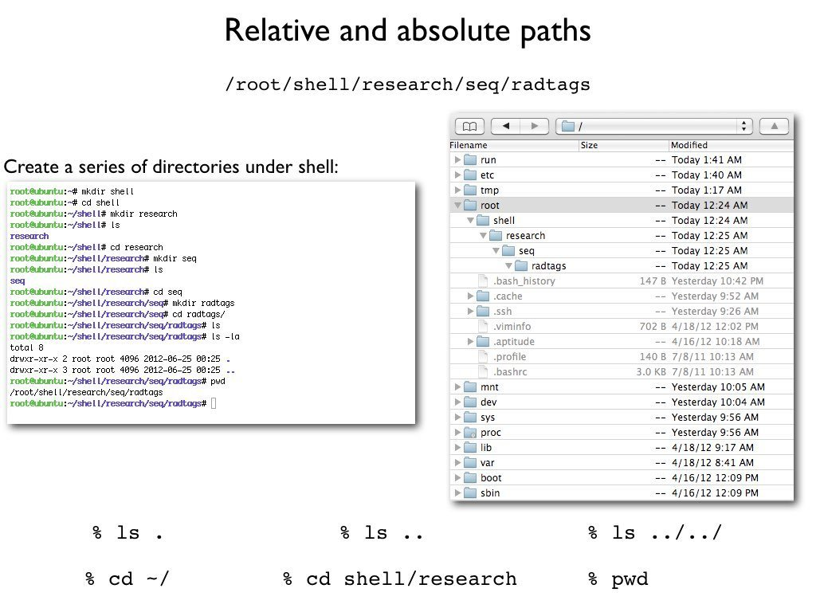

# Navigating the file system and working with files using Shell Commands

## Navigating the File System

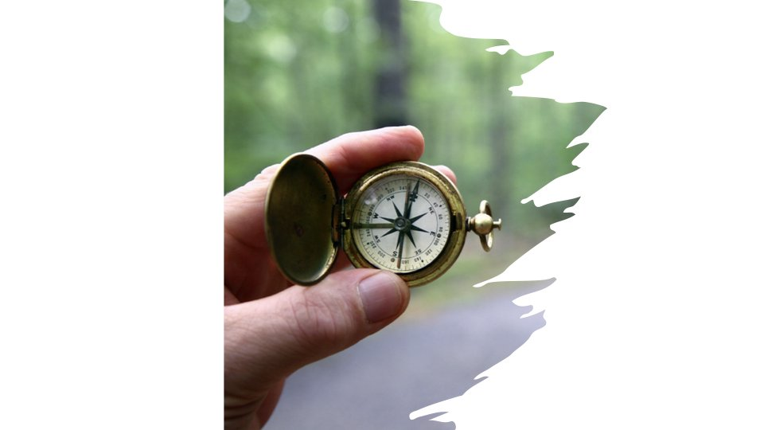

## Common Navigation Commands

| Command | Description | Common Options |
| --- | --- | --- |
| `pwd` | Print working directory | (In Windows, `cd` prints working directory) |
| `ls` | List directories and files | `-F`, `-l`, `-r`, `-S`, `-t` |
| `cd` | Change directory | `..` (up one level), `-` (previous) |

## Common File Commands

| Command | Function |
| --- | --- |
| `mkdir` | Make new folders |
| `nano`, `touch` | Make new files |
| `mv` | Rename or move files |
| `cp` | Copy files |
| `rm` | Delete files |
| `wc` | Word count / file length |
| `cat` | Reading/concatenating files |
| `head`, `tail` | View beginning or end of files |

## Naming Conventions

- Avoid spaces in file names
- Don’t start with a `–`
- Stick to letters, numbers, `.`, `-`, and `_`
- Use appropriate file extensions (.fasta, .txt, etc.)

**The shell trusts you**

It will delete files you say to delete and override files with duplicate names!

## Getting Help

**Manual pages:**

- Type `man [command_name]` to access the manual
- Type `q` to exit

**Also…the internet!**

- Stack Overflow, GitHub discussions, official documentation

## Exercise

**Exercise**

1. Make a new directory and add a file named `practice.txt` with some text
2. Read the contents and get its length
3. Rename the file to `super_practice.txt`
4. Move it to a new folder named `sandbox`
5. Make a copy named `super_practice_copy.txt`
6. Verify the contents match, then delete the original

# R and RStudio

## Why use R?

[figure not shown]

- Powerful, flexible, and free
- Runs on all platforms
- Superb data management & graphics capabilities
- Thousands of community-contributed packages
- Embed analyses in dynamic documents using Quarto
- Lots of online help available

Source: imgflip.com

## R Resources

| Resource | URL |
| --- | --- |
| The R Project | http://www.r-project.org |
| RStudio | http://www.rstudio.com |
| R for Data Science | https://r4ds.had.co.nz |
| Quick R | http://www.statmethods.net |
| Bioconductor | http://www.bioconductor.org |
| Stack Overflow | https://stackoverflow.com/questions/tagged/r |

**Tip**

When you get an error, paste it into Google—someone else has had the same problem!

## RStudio Interface

[figure not shown]

**Tip**

`R` is the programming language, `RStudio` is the Integrated Developer Environment (IDE) to let you write scripts in `R` (and other languages like `Python` and `C++`)

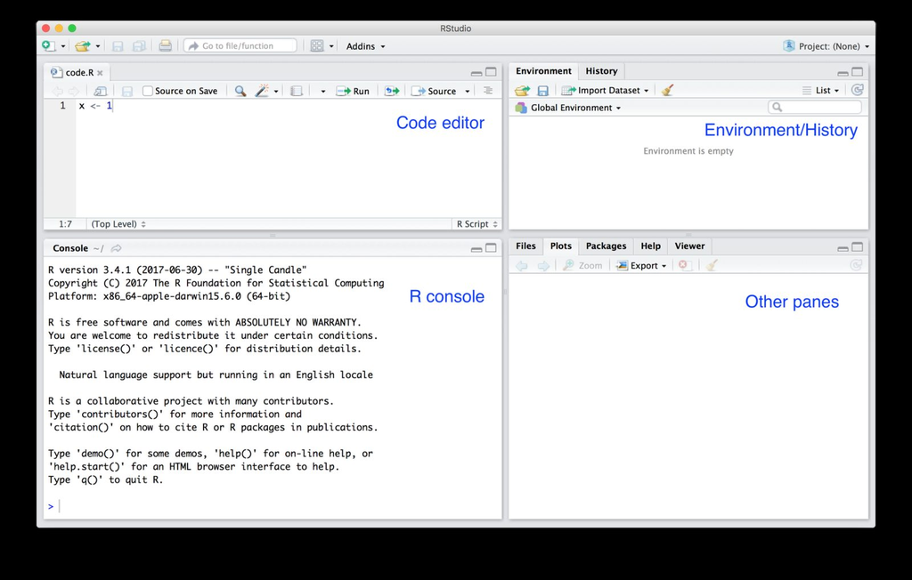

| Pane | Location | Purpose |
| --- | --- | --- |
| **Code Editor** | Top-left | Write/edit scripts, view data |
| **Console** | Bottom-left | Interactive R session |
| **Environment** | Top-right | View objects, command history |
| **Files/Plots/Help** | Bottom-right | Navigate files, view plots, get help |

**Tip**

Customize layout in Tools → Global Options → Pane Layout

Source: RStudio IDE, Posit Software PBC

## Installing and Loading Packages

R’s power comes from community-contributed packages:

- **Install once** (downloads package)
- **Load each session** (makes functions available)
- Install
- Load

```r
install.packages("tidyverse")
```

```r
library(tidyverse)
```

**Note**

Also install via RStudio: Tools → Install Packages

## The Tidyverse Ecosystem

| Package | Purpose |
| --- | --- |
| `dplyr` | Data manipulation (filter, select, mutate, summarize) |
| `ggplot2` | Data visualization |
| `tidyr` | Reshaping data (pivot, separate, unite) |
| `readr` | Fast reading of CSV, TSV files |
| `stringr` | String manipulation |
| `purrr` | Functional programming tools |

Loading `tidyverse` loads all of these at once!

# R Basics

## R Script Basics

- A series of R commands that will be executed
- Add comments using hashtags `#`
- Use pipes to connect steps

**Best Practice**

Always comment your code! Future you will thank present you.

## Basic Math in R

- Commands submitted through terminal, console, or scripts
- Anything following `#` is a comment
- R follows standard mathematical order of operations
- Output
- Code
- Interpretation

```
[1] 16
```

```
[1] 16
```

```r
4*4
(4+3*2^2)
```

## Assigning Variables

- Use the `<-` operator
- Names must begin with a letter
- R is case sensitive
- Output
- Code
- Interpretation

```
[1] 6
```

```
[1] 4
```

```r
x <- 2
x*3
y <- x * 3
y-2
```

- The `<-` operator assigns values to variables. Variables can then be used in expressions. Note that `y` stores the result of `x * 3`, not the formula itself.

These do **not** work: `3y <- 3` or `3*y <- 3`

## Arithmetic and Functions

- Output
- Code
- Interpretation

```
[1] 69022864
```

```r
x+2
x^2
log(x)

y <- 67
x <- 124
z <- (x*y)^2
print(z)
```

[output not shown]

- R has many built-in mathematical functions like `log()`. Results of calculations can be assigned to new variables for later use.

## Common Data Types

| Statistical Term | Description | R Type |
| --- | --- | --- |
| Numerical (continuous) | Measurements (height, weight) | `numeric` |
| Numerical (discrete) | Whole number counts | `integer` |
| Categorical (nominal) | Unordered categories (species) | `factor` |
| Categorical (ordinal) | Ordered categories (low/med/high) | `ordered factor` |
| Logical / Boolean | TRUE or FALSE values | `logical` |
| Text / String | Free-form text | `character` |
| Date / Time | Temporal data | `Date`, `POSIXct` |

**Tip**

Use `class()` or `str()` to check data types

## Strings

- Characters need quotation marks
- `c()` stands for `concatenate`
- Output
- Code
- Interpretation

```
[1] "I Love"        "Biostatistics"
```

```r
x <- "I Love"
y <- "Biostatistics"
z <- c(x,y)
print(z)
```

- Character strings require quotation marks. The `c()` function concatenates elements into a vector. Here it creates a character vector with two elements.

## Factors

- Sometimes we want to treat characters as units for calculations
- These are called `factors`—important for statistical analyses comparing groups
- Output
- Code
- Interpretation

```
[1] low, medium, high
Levels: low, medium, high
```

```r
z <- "low, medium, high"
z_factor <- as.factor(z)
print(z_factor)
```

- Factors are R’s way of representing categorical variables. The `as.factor()` function converts character strings into factor levels, which is essential for statistical analyses comparing groups.

## Data Type Coercion

Convert between data types using `as.*` functions:

| Function | Input | Output |
| --- | --- | --- |
| `as.numeric("42")` | `"42"` | `42` |
| `as.numeric("hello")` | `"hello"` | `NA` (with warning) |
| `as.character(42)` | `42` | `"42"` |
| `as.logical(1)` | `1` | `TRUE` |
| `as.logical(0)` | `0` | `FALSE` |

**Warning**

`as.numeric()` on a factor returns integer codes! Use `as.numeric(as.character(x))` instead.

## Vectors

R thinks in terms of vectors (lists of values):

- Output
- Code
- Interpretation

```
 [1]  2  3  4  2  1  2  4  5 10  8  9
```

```r
x <- c(2,3,4,2,1,2,4,5,10,8,9)
print(x)
```

- Vectors are the fundamental data structure in R. The `c()` function creates a vector from individual values. R applies operations element-wise to vectors.

## Creating Vectors

Use functions like `seq` and `sample`:

- Output
- Code
- Interpretation

```
  [1]  0.0  0.1  0.2  0.3  0.4  0.5  0.6  0.7  0.8  0.9  1.0  1.1  1.2  1.3  1.4
 [16]  1.5  1.6  1.7  1.8  1.9  2.0  2.1  2.2  2.3  2.4  2.5  2.6  2.7  2.8  2.9
 [31]  3.0  3.1  3.2  3.3  3.4  3.5  3.6  3.7  3.8  3.9  4.0  4.1  4.2  4.3  4.4
 [46]  4.5  4.6  4.7  4.8  4.9  5.0  5.1  5.2  5.3  5.4  5.5  5.6  5.7  5.8  5.9
 [61]  6.0  6.1  6.2  6.3  6.4  6.5  6.6  6.7  6.8  6.9  7.0  7.1  7.2  7.3  7.4
 [76]  7.5  7.6  7.7  7.8  7.9  8.0  8.1  8.2  8.3  8.4  8.5  8.6  8.7  8.8  8.9
 [91]  9.0  9.1  9.2  9.3  9.4  9.5  9.6  9.7  9.8  9.9 10.0
```

```
  [1] 100.00  98.01  96.04  94.09  92.16  90.25  88.36  86.49  84.64  82.81
 [11]  81.00  79.21  77.44  75.69  73.96  72.25  70.56  68.89  67.24  65.61
 [21]  64.00  62.41  60.84  59.29  57.76  56.25  54.76  53.29  51.84  50.41
 [31]  49.00  47.61  46.24  44.89  43.56  42.25  40.96  39.69  38.44  37.21
 [41]  36.00  34.81  33.64  32.49  31.36  30.25  29.16  28.09  27.04  26.01
 [51]  25.00  24.01  23.04  22.09  21.16  20.25  19.36  18.49  17.64  16.81
 [61]  16.00  15.21  14.44  13.69  12.96  12.25  11.56  10.89  10.24   9.61
 [71]   9.00   8.41   7.84   7.29   6.76   6.25   5.76   5.29   4.84   4.41
 [81]   4.00   3.61   3.24   2.89   2.56   2.25   1.96   1.69   1.44   1.21
 [91]   1.00   0.81   0.64   0.49   0.36   0.25   0.16   0.09   0.04   0.01
[101]   0.00
```

```r
seq_1 <- seq(0.0, 10.0, by = 0.1)
print(seq_1)
seq_2 <- seq(10.0, 0.0, by = -0.1)
seq_square <- (seq_2)^2
print(seq_square)
```

- `seq()` generates regular sequences. Vectorized operations like squaring apply to every element simultaneously, making R efficient for numerical computation.

## Basic Statistics Functions on Vectors

| Function | Description |
| --- | --- |
| `mean(x)` | Calculate the mean |
| `median(x)` | Calculate the median |
| `var(x)` | Calculate the variance |
| `sd(x)` | Calculate the standard deviation |
| `sum(x)` | Sum of all values |
| `length(x)` | Number of elements |
| `sample(x, replace=T)` | Random sample with replacement |

**Note**

All of these can function on vectors which are assigned to a variable (e.g. x above)

## Logical Operators

| Operator | Meaning | Example |
| --- | --- | --- |
| `==` | equals | `x == 5` |
| `!=` | not equals | `x != 5` |
| `<`, `>` | less/greater than | `x < 10` |
| `&` | and | `x > 0 & x < 10` |
| `\|` | or | `x < 0 \| x > 10` |
| `%in%` | is element of | `x %in% c(1, 2, 3)` |

- Output
- Code
- Interpretation

```
[1] FALSE FALSE FALSE  TRUE  TRUE
```

```
[1] 15 20
```

```r
x <- c(1, 5, 10, 15, 20)
x > 10
x[x > 10]
```

- Logical operators return TRUE/FALSE values. Square bracket indexing `x[x > 10]` filters a vector to keep only elements meeting the condition — a powerful pattern used throughout R programming.

## Handling Missing Data (NA)

| Task | Code | Result |
| --- | --- | --- |
| Check for NA | `is.na(x)` | Logical vector |
| Find non-missing | `!is.na(x)` | Inverted logical |
| **Don’t do this!** | `x == NA` | Always returns NA |
| Mean ignoring NA | `mean(x, na.rm=TRUE)` | Computes mean |

**Important**

Always use `is.na()` to check for missing values, never `== NA`

## Special Numeric Values

| Value | Meaning | Example |
| --- | --- | --- |
| `NA` | Not Available (missing data) | `c(1, NA, 3)` |
| `NaN` | Not a Number (undefined math) | `0/0` |
| `Inf` | Positive infinity | `1/0` |
| `-Inf` | Negative infinity | `-1/0` |

Test with: `is.na()`, `is.nan()`, `is.infinite()`, `is.finite()`

## Getting Help in R

| Command | Description |
| --- | --- |
| `help(mean)` or `?mean` | Open help page |
| `example(mean)` | Run examples from help |
| `help.search("mean")` | Search all help pages |
| `args(mean)` | Show function arguments |

## Working Directory

| Task | Code |
| --- | --- |
| Check current directory | `getwd()` |
| Set new directory | `setwd("/path/to/folder")` |
| List files | `list.files()` |

**Tip**

RStudio Projects (File → New Project) automatically set your working directory

## Common R Errors

| Error Message | Meaning | Fix |
| --- | --- | --- |
| `object 'x' not found` | Variable doesn’t exist | Check spelling; run line that creates it |
| `could not find function` | Package not loaded | Use `library()` or check spelling |
| `unexpected ')'` | Mismatched brackets | Count opening/closing brackets |
| `non-numeric argument` | Wrong data type | Check with `class()` |

**Tip**

Read error messages from the bottom up—the last line tells you what went wrong

# A few examples of basic R code

## Drawing Samples from Distributions

- Output
- Code
- Interpretation

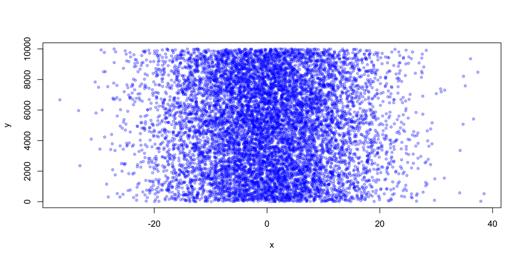

Figure 1: Random samples from distributions

```r
x <- rnorm(10000, 0, 10)
y <- sample(1:10000, 10000, replace = T)
plot(x, y, pch = 20, col = rgb(0, 0, 1, 0.3))
```

## Histograms

- Output
- Code
- Interpretation

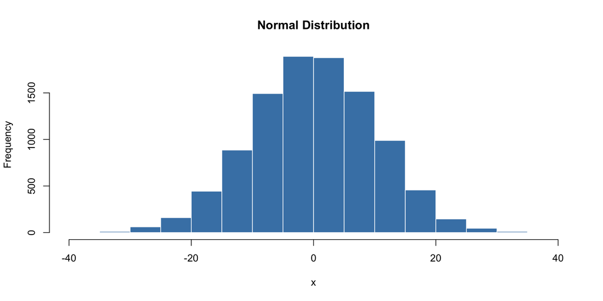

Figure 2: Histogram of normally distributed data

```r
x <- rnorm(10000, 0, 10)
hist(x, col = "steelblue", border = "white", main = "Normal Distribution")
```

- The histogram shows the frequency distribution of 10,000 values drawn from N(0,10). The bell-shaped curve confirms the normal distribution. The `col` and `border` arguments improve readability.

## Density Curves

- Output
- Code
- Interpretation

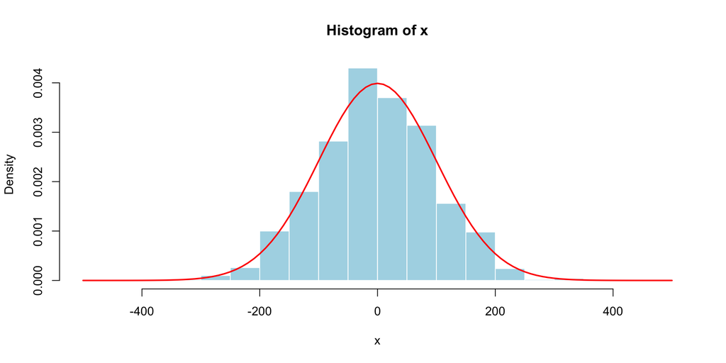

Figure 3: Histogram with density curve overlay

```r
x <- rnorm(1000, 0, 100)
hist(x, xlim = c(-500,500), col = "lightblue", border = "white", freq = FALSE)
curve(dnorm(x, 0, 100), xlim = c(-500,500), add=TRUE, col='Red', lwd=2)
```

- Setting `freq=FALSE` converts the y-axis to probability density, allowing the theoretical curve overlay via `curve()`. The close match between histogram and curve confirms our sample approximates the theoretical distribution.

## Binomial Distribution

- Output
- Code
- Interpretation

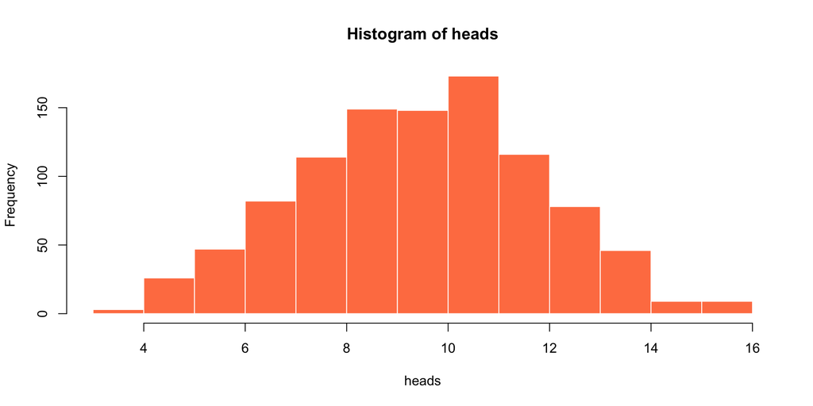

Figure 4: Binomial distribution: 10 successes (out of 20 trials) is most frequent

```r
heads <- rbinom(n=1000, size=20, prob=0.5)
hist(heads, col = "coral", border = "white")
```

- With n=20 trials and p=0.5, the most likely outcome is 10 successes, forming a symmetric distribution. This simulates scenarios like coin flips or Mendelian heterozygote crosses.

## Multiple Plots

Use `par(mfrow=c(rows, cols))` to create composite figures:

- Output
- Code
- Interpretation

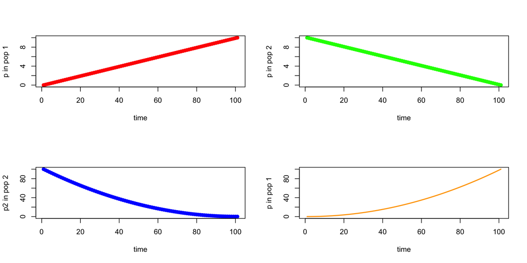

Figure 5: Multiple plots in a single figure

```r
seq_1 <- seq(0.0, 10.0, by = 0.1)
seq_2 <- seq(10.0, 0.0, by = -0.1)

par(mfrow=c(2,2))
plot(seq_1, xlab="time", ylab="p in pop 1", type = "p", col = 'red', pch = 19)
plot(seq_2, xlab="time", ylab="p in pop 2", type = "p", col = 'green', pch = 19)
plot((seq_2)^2, xlab="time", ylab="p2 in pop 2", type = "p", col = 'blue', pch = 19)
plot((seq_1)^2, xlab="time", ylab ="p in pop 1", type = "l", col = 'orange', lwd = 2)
```

- `par(mfrow=c(2,2))` creates a 2x2 grid layout. Different `type` arguments control display — `"p"` for points, `"l"` for lines. This technique is useful for comparing related datasets or showing different views of the same data.